# W3cubDocs

/GTK 3.24

# GtkWindow

GtkWindow — Toplevel which can contain other widgets

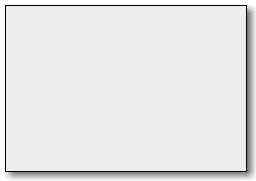

## Functions

| GtkWidget * | gtk_window_new () |
| --- | --- |
| void | gtk_window_set_title () |
| void | gtk_window_set_wmclass () |
| void | gtk_window_set_resizable () |
| gboolean | gtk_window_get_resizable () |
| void | gtk_window_add_accel_group () |
| void | gtk_window_remove_accel_group () |
| gboolean | gtk_window_activate_focus () |
| gboolean | gtk_window_activate_default () |
| void | gtk_window_set_modal () |
| void | gtk_window_set_default_size () |
| void | gtk_window_set_default_geometry () |
| void | gtk_window_set_geometry_hints () |
| void | gtk_window_set_gravity () |
| GdkGravity | gtk_window_get_gravity () |
| void | gtk_window_set_position () |
| void | gtk_window_set_transient_for () |
| void | gtk_window_set_attached_to () |
| void | gtk_window_set_destroy_with_parent () |
| void | gtk_window_set_hide_titlebar_when_maximized () |
| void | gtk_window_set_screen () |
| [GdkScreen](https://developer.gnome.org/gtk3/html/GdkScreen.html#GdkScreen-struct) * | gtk_window_get_screen () |
| gboolean | gtk_window_is_active () |
| gboolean | gtk_window_is_maximized () |
| gboolean | gtk_window_has_toplevel_focus () |
| GList * | gtk_window_list_toplevels () |
| void | gtk_window_add_mnemonic () |
| void | gtk_window_remove_mnemonic () |
| gboolean | gtk_window_mnemonic_activate () |
| gboolean | gtk_window_activate_key () |
| gboolean | gtk_window_propagate_key_event () |

[output cut: 88 more lines]

## Properties

| gboolean | accept-focus | Read / Write |
| --- | --- | --- |
| GtkApplication * | application | Read / Write |
| GtkWidget * | attached-to | Read / Write / Construct |
| gboolean | decorated | Read / Write |
| int | default-height | Read / Write |
| int | default-width | Read / Write |
| gboolean | deletable | Read / Write |
| gboolean | destroy-with-parent | Read / Write |
| gboolean | focus-on-map | Read / Write |
| gboolean | focus-visible | Read / Write |
| GdkGravity | gravity | Read / Write |
| gboolean | has-resize-grip | Read / Write |
| gboolean | has-toplevel-focus | Read |
| gboolean | hide-titlebar-when-maximized | Read / Write |
| [GdkPixbuf](https://developer.gnome.org/gdk-pixbuf/unstable//gdk-pixbuf-The-GdkPixbuf-Structure.html#GdkPixbuf-struct) * | icon | Read / Write |
| char * | icon-name | Read / Write |
| gboolean | is-active | Read |
| gboolean | is-maximized | Read |
| gboolean | mnemonics-visible | Read / Write |
| gboolean | modal | Read / Write |
| gboolean | resizable | Read / Write |
| gboolean | resize-grip-visible | Read |
| char * | role | Read / Write |
| [GdkScreen](https://developer.gnome.org/gtk3/html/GdkScreen.html#GdkScreen-struct) * | screen | Read / Write |
| gboolean | skip-pager-hint | Read / Write |
| gboolean | skip-taskbar-hint | Read / Write |
| char * | startup-id | Write |
| char * | title | Read / Write |
| GtkWindow * | transient-for | Read / Write / Construct |
| GtkWindowType | type | Read / Write / Construct Only |
| GdkWindowTypeHint | type-hint | Read / Write |
| gboolean | urgency-hint | Read / Write |
| GtkWindowPosition | window-position | Read / Write |

## Style Properties

| char * | decoration-button-layout | Read |
| --- | --- | --- |
| int | decoration-resize-handle | Read / Write |

## Signals

| void | activate-default | Action |
| --- | --- | --- |
| void | activate-focus | Action |
| gboolean | enable-debugging | Action |
| void | keys-changed | Run First |
| void | set-focus | Run Last |

## Types and Values

|  | GtkWindow |
| --- | --- |
| struct | GtkWindowClass |
| enum | GtkWindowType |
| enum | GtkWindowPosition |

## Object Hierarchy

```
    GObject
    ╰── GInitiallyUnowned
        ╰── GtkWidget
            ╰── GtkContainer
                ╰── GtkBin
                    ╰── GtkWindow
                        ├── GtkDialog
                        ├── GtkApplicationWindow
                        ├── GtkAssistant
                        ├── GtkOffscreenWindow
                        ├── GtkPlug
                        ╰── GtkShortcutsWindow
```

## Implemented Interfaces

GtkWindow implements AtkImplementorIface and GtkBuildable.

## Includes

```
#include <gtk/gtk.h>
```

## Description

A GtkWindow is a toplevel window which can contain other widgets. Windows normally have decorations that are under the control of the windowing system and allow the user to manipulate the window (resize it, move it, close it,...).

### GtkWindow as GtkBuildable

The GtkWindow implementation of the GtkBuildable interface supports a custom <accel-groups> element, which supports any number of <group> elements representing the GtkAccelGroup objects you want to add to your window (synonymous with `gtk_window_add_accel_group()`.

It also supports the <initial-focus> element, whose name property names the widget to receive the focus when the window is mapped.

The GtkWindow implementation of the GtkBuildable interface supports setting a child as the titlebar by specifying “titlebar” as the “type” attribute of a <child> element.

### CSS nodes

GtkWindow has a main CSS node with name window and style class .background, and a subnode with name decoration.

Style classes that are typically used with the main CSS node are .csd (when client-side decorations are in use), .solid-csd (for client-side decorations without invisible borders), .ssd (used by mutter when rendering server-side decorations). GtkWindow also represents window states with the following style classes on the main node: .tiled, .maximized, .fullscreen. Specialized types of window often add their own discriminating style classes, such as .popup or .tooltip.

GtkWindow adds the .titlebar and .default-decoration style classes to the widget that is added as a titlebar child.

## Functions

### gtk_window_new ()

```
GtkWidget *
gtk_window_new (GtkWindowType type);
```

Creates a new GtkWindow, which is a toplevel window that can contain other widgets. Nearly always, the type of the window should be GTK_WINDOW_TOPLEVEL. If you’re implementing something like a popup menu from scratch (which is a bad idea, just use GtkMenu), you might use GTK_WINDOW_POPUP. GTK_WINDOW_POPUP is not for dialogs, though in some other toolkits dialogs are called “popups”. In GTK+, GTK_WINDOW_POPUP means a pop-up menu or pop-up tooltip. On X11, popup windows are not controlled by the window manager.

If you simply want an undecorated window (no window borders), use `gtk_window_set_decorated()`, don’t use GTK_WINDOW_POPUP.

All top-level windows created by `gtk_window_new()` are stored in an internal top-level window list. This list can be obtained from `gtk_window_list_toplevels()`. Due to Gtk+ keeping a reference to the window internally, `gtk_window_new()` does not return a reference to the caller.

To delete a GtkWindow, call `gtk_widget_destroy()`.

#### Parameters

| type | type of window |  |
| --- | --- | --- |

#### Returns

a new GtkWindow.

### gtk_window_set_title ()

```
void
gtk_window_set_title (GtkWindow *window,
                      const gchar *title);
```

Sets the title of the GtkWindow. The title of a window will be displayed in its title bar; on the X Window System, the title bar is rendered by the window manager, so exactly how the title appears to users may vary according to a user’s exact configuration. The title should help a user distinguish this window from other windows they may have open. A good title might include the application name and current document filename, for example.

#### Parameters

| window | a GtkWindow |  |
| --- | --- | --- |
| title | title of the window |  |

### gtk_window_set_wmclass ()

```
void
gtk_window_set_wmclass (GtkWindow *window,
                        const gchar *wmclass_name,
                        const gchar *wmclass_class);
```

`gtk_window_set_wmclass` has been deprecated since version 3.22 and should not be used in newly-written code.

Don’t use this function. It sets the X Window System “class” and “name” hints for a window. According to the ICCCM, you should always set these to the same value for all windows in an application, and GTK+ sets them to that value by default, so calling this function is sort of pointless. However, you may want to call `gtk_window_set_role()` on each window in your application, for the benefit of the session manager. Setting the role allows the window manager to restore window positions when loading a saved session.

#### Parameters

| window | a GtkWindow |  |
| --- | --- | --- |
| wmclass_name | window name hint |  |
| wmclass_class | window class hint |  |

### gtk_window_set_resizable ()

```
void
gtk_window_set_resizable (GtkWindow *window,
                          gboolean resizable);
```

Sets whether the user can resize a window. Windows are user resizable by default.

#### Parameters

| window | a GtkWindow |  |
| --- | --- | --- |
| resizable | `TRUE` if the user can resize this window |  |

### gtk_window_get_resizable ()

```
gboolean
gtk_window_get_resizable (GtkWindow *window);
```

Gets the value set by `gtk_window_set_resizable()`.

#### Parameters

| window | a GtkWindow |  |
| --- | --- | --- |

#### Returns

`TRUE` if the user can resize the window

### gtk_window_add_accel_group ()

```
void
gtk_window_add_accel_group (GtkWindow *window,
                            GtkAccelGroup *accel_group);
```

Associate *`accel_group`* with *`window`* , such that calling `gtk_accel_groups_activate()` on *`window`* will activate accelerators in *`accel_group`* .

#### Parameters

| window | window to attach accelerator group to |  |
| --- | --- | --- |
| accel_group | a GtkAccelGroup |  |

### gtk_window_remove_accel_group ()

```
void
gtk_window_remove_accel_group (GtkWindow *window,
                               GtkAccelGroup *accel_group);
```

Reverses the effects of `gtk_window_add_accel_group()`.

#### Parameters

| window | a GtkWindow |  |
| --- | --- | --- |
| accel_group | a GtkAccelGroup |  |

### gtk_window_activate_focus ()

```
gboolean
gtk_window_activate_focus (GtkWindow *window);
```

Activates the current focused widget within the window.

#### Parameters

| window | a GtkWindow |  |
| --- | --- | --- |

#### Returns

`TRUE` if a widget got activated.

### gtk_window_activate_default ()

```
gboolean
gtk_window_activate_default (GtkWindow *window);
```

Activates the default widget for the window, unless the current focused widget has been configured to receive the default action (see `gtk_widget_set_receives_default()`), in which case the focused widget is activated.

#### Parameters

| window | a GtkWindow |  |
| --- | --- | --- |

#### Returns

`TRUE` if a widget got activated.

### gtk_window_set_modal ()

```
void
gtk_window_set_modal (GtkWindow *window,
                      gboolean modal);
```

Sets a window modal or non-modal. Modal windows prevent interaction with other windows in the same application. To keep modal dialogs on top of main application windows, use `gtk_window_set_transient_for()` to make the dialog transient for the parent; most window managers will then disallow lowering the dialog below the parent.

#### Parameters

| window | a GtkWindow |  |
| --- | --- | --- |
| modal | whether the window is modal |  |

### gtk_window_set_default_size ()

```
void
gtk_window_set_default_size (GtkWindow *window,
                             gint width,
                             gint height);
```

Sets the default size of a window. If the window’s “natural” size (its size request) is larger than the default, the default will be ignored. More generally, if the default size does not obey the geometry hints for the window (`gtk_window_set_geometry_hints()` can be used to set these explicitly), the default size will be clamped to the nearest permitted size.

Unlike `gtk_widget_set_size_request()`, which sets a size request for a widget and thus would keep users from shrinking the window, this function only sets the initial size, just as if the user had resized the window themselves. Users can still shrink the window again as they normally would. Setting a default size of -1 means to use the “natural” default size (the size request of the window).

For more control over a window’s initial size and how resizing works, investigate `gtk_window_set_geometry_hints()`.

For some uses, `gtk_window_resize()` is a more appropriate function. `gtk_window_resize()` changes the current size of the window, rather than the size to be used on initial display. `gtk_window_resize()` always affects the window itself, not the geometry widget.

The default size of a window only affects the first time a window is shown; if a window is hidden and re-shown, it will remember the size it had prior to hiding, rather than using the default size.

Windows can’t actually be 0x0 in size, they must be at least 1x1, but passing 0 for *`width`* and *`height`* is OK, resulting in a 1x1 default size.

If you use this function to reestablish a previously saved window size, note that the appropriate size to save is the one returned by `gtk_window_get_size()`. Using the window allocation directly will not work in all circumstances and can lead to growing or shrinking windows.

#### Parameters

| window | a GtkWindow |  |
| --- | --- | --- |
| width | width in pixels, or -1 to unset the default width |  |
| height | height in pixels, or -1 to unset the default height |  |

### gtk_window_set_default_geometry ()

```
void
gtk_window_set_default_geometry (GtkWindow *window,
                                 gint width,
                                 gint height);
```

`gtk_window_set_default_geometry` has been deprecated since version 3.20 and should not be used in newly-written code.

This function does nothing. If you want to set a default size, use `gtk_window_set_default_size()` instead.

Like `gtk_window_set_default_size()`, but *`width`* and *`height`* are interpreted in terms of the base size and increment set with gtk_window_set_geometry_hints.

#### Parameters

| window | a GtkWindow |  |
| --- | --- | --- |
| width | width in resize increments, or -1 to unset the default width |  |
| height | height in resize increments, or -1 to unset the default height |  |

Since: 3.0

### gtk_window_set_geometry_hints ()

```
void
gtk_window_set_geometry_hints (GtkWindow *window,
                               GtkWidget *geometry_widget,
                               GdkGeometry *geometry,
                               GdkWindowHints geom_mask);
```

This function sets up hints about how a window can be resized by the user. You can set a minimum and maximum size; allowed resize increments (e.g. for xterm, you can only resize by the size of a character); aspect ratios; and more. See the GdkGeometry struct.

#### Parameters

| window | a GtkWindow |  |
| --- | --- | --- |
| geometry_widget | widget the geometry hints used to be applied to or `NULL`. Since 3.20 this argument is ignored and GTK behaves as if `NULL` was set. | [allow-none] |
| geometry | struct containing geometry information or `NULL`. | [allow-none] |
| geom_mask | mask indicating which struct fields should be paid attention to |  |

### gtk_window_set_gravity ()

```
void
gtk_window_set_gravity (GtkWindow *window,
                        GdkGravity gravity);
```

Window gravity defines the meaning of coordinates passed to `gtk_window_move()`. See `gtk_window_move()` and GdkGravity for more details.

The default window gravity is [GDK_GRAVITY_NORTH_WEST](https://developer.gnome.org/gtk3/html/gdk3-Windows.html#GDK-GRAVITY-NORTH-WEST:CAPS) which will typically “do what you mean.”

#### Parameters

| window | a GtkWindow |  |
| --- | --- | --- |
| gravity | window gravity |  |

### gtk_window_get_gravity ()

```
GdkGravity
gtk_window_get_gravity (GtkWindow *window);
```

Gets the value set by `gtk_window_set_gravity()`.

#### Parameters

| window | a GtkWindow |  |
| --- | --- | --- |

#### Returns

window gravity.

[transfer none]

### gtk_window_set_position ()

```
void
gtk_window_set_position (GtkWindow *window,
                         GtkWindowPosition position);
```

Sets a position constraint for this window. If the old or new constraint is `GTK_WIN_POS_CENTER_ALWAYS`, this will also cause the window to be repositioned to satisfy the new constraint.

#### Parameters

| window | a GtkWindow. |  |
| --- | --- | --- |
| position | a position constraint. |  |

### gtk_window_set_transient_for ()

```
void
gtk_window_set_transient_for (GtkWindow *window,
                              GtkWindow *parent);
```

Dialog windows should be set transient for the main application window they were spawned from. This allows window managers to e.g. keep the dialog on top of the main window, or center the dialog over the main window. `gtk_dialog_new_with_buttons()` and other convenience functions in GTK+ will sometimes call `gtk_window_set_transient_for()` on your behalf.

Passing `NULL` for *`parent`* unsets the current transient window.

On Wayland, this function can also be used to attach a new GTK_WINDOW_POPUP to a GTK_WINDOW_TOPLEVEL parent already mapped on screen so that the GTK_WINDOW_POPUP will be created as a subsurface-based window [GDK_WINDOW_SUBSURFACE](https://developer.gnome.org/gtk3/html/gdk3-Windows.html#GDK-WINDOW-SUBSURFACE:CAPS) which can be positioned at will relatively to the GTK_WINDOW_TOPLEVEL surface.

On Windows, this function puts the child window on top of the parent, much as the window manager would have done on X.

#### Parameters

| window | a GtkWindow |  |
| --- | --- | --- |
| parent | parent window, or `NULL`. | [allow-none] |

### gtk_window_set_attached_to ()

```
void
gtk_window_set_attached_to (GtkWindow *window,
                            GtkWidget *attach_widget);
```

Marks *`window`* as attached to *`attach_widget`* . This creates a logical binding between the window and the widget it belongs to, which is used by GTK+ to propagate information such as styling or accessibility to *`window`* as if it was a children of *`attach_widget`* .

Examples of places where specifying this relation is useful are for instance a GtkMenu created by a GtkComboBox, a completion popup window created by GtkEntry or a typeahead search entry created by GtkTreeView.

Note that this function should not be confused with `gtk_window_set_transient_for()`, which specifies a window manager relation between two toplevels instead.

Passing `NULL` for *`attach_widget`* detaches the window.

#### Parameters

| window | a GtkWindow |  |
| --- | --- | --- |
| attach_widget | a GtkWidget, or `NULL`. | [allow-none] |

Since: 3.4

### gtk_window_set_destroy_with_parent ()

```
void
gtk_window_set_destroy_with_parent (GtkWindow *window,
                                    gboolean setting);
```

If *`setting`* is `TRUE`, then destroying the transient parent of *`window`* will also destroy *`window`* itself. This is useful for dialogs that shouldn’t persist beyond the lifetime of the main window they're associated with, for example.

#### Parameters

| window | a GtkWindow |  |
| --- | --- | --- |
| setting | whether to destroy *`window`* with its transient parent |  |

### gtk_window_set_hide_titlebar_when_maximized ()

```
void
gtk_window_set_hide_titlebar_when_maximized
                               (GtkWindow *window,
                                gboolean setting);
```

If *`setting`* is `TRUE`, then *`window`* will request that it’s titlebar should be hidden when maximized. This is useful for windows that don’t convey any information other than the application name in the titlebar, to put the available screen space to better use. If the underlying window system does not support the request, the setting will not have any effect.

Note that custom titlebars set with `gtk_window_set_titlebar()` are not affected by this. The application is in full control of their content and visibility anyway.

#### Parameters

| window | a GtkWindow |  |
| --- | --- | --- |
| setting | whether to hide the titlebar when *`window`* is maximized |  |

Since: 3.4

### gtk_window_set_screen ()

```
void
gtk_window_set_screen (GtkWindow *window,
                       GdkScreen *screen);
```

Sets the [GdkScreen](https://developer.gnome.org/gtk3/html/GdkScreen.html#GdkScreen-struct) where the *`window`* is displayed; if the window is already mapped, it will be unmapped, and then remapped on the new screen.

#### Parameters

| window | a GtkWindow. |  |
| --- | --- | --- |
| screen | a [GdkScreen](https://developer.gnome.org/gtk3/html/GdkScreen.html#GdkScreen-struct). |  |

Since: 2.2

### gtk_window_get_screen ()

```
GdkScreen *
gtk_window_get_screen (GtkWindow *window);
```

Returns the [GdkScreen](https://developer.gnome.org/gtk3/html/GdkScreen.html#GdkScreen-struct) associated with *`window`* .

#### Parameters

| window | a GtkWindow. |  |
| --- | --- | --- |

#### Returns

a [GdkScreen](https://developer.gnome.org/gtk3/html/GdkScreen.html#GdkScreen-struct).

[transfer none]

Since: 2.2

### gtk_window_is_active ()

```
gboolean
gtk_window_is_active (GtkWindow *window);
```

Returns whether the window is part of the current active toplevel. (That is, the toplevel window receiving keystrokes.) The return value is `TRUE` if the window is active toplevel itself, but also if it is, say, a GtkPlug embedded in the active toplevel. You might use this function if you wanted to draw a widget differently in an active window from a widget in an inactive window. See `gtk_window_has_toplevel_focus()`

#### Parameters

| window | a GtkWindow |  |
| --- | --- | --- |

#### Returns

`TRUE` if the window part of the current active window.

Since: 2.4

### gtk_window_is_maximized ()

```
gboolean
gtk_window_is_maximized (GtkWindow *window);
```

Retrieves the current maximized state of *`window`* .

Note that since maximization is ultimately handled by the window manager and happens asynchronously to an application request, you shouldn’t assume the return value of this function changing immediately (or at all), as an effect of calling `gtk_window_maximize()` or `gtk_window_unmaximize()`.

#### Parameters

| window | a GtkWindow |  |
| --- | --- | --- |

#### Returns

whether the window has a maximized state.

Since: 3.12

### gtk_window_has_toplevel_focus ()

```
gboolean
gtk_window_has_toplevel_focus (GtkWindow *window);
```

Returns whether the input focus is within this GtkWindow. For real toplevel windows, this is identical to `gtk_window_is_active()`, but for embedded windows, like GtkPlug, the results will differ.

#### Parameters

| window | a GtkWindow |  |
| --- | --- | --- |

#### Returns

`TRUE` if the input focus is within this GtkWindow

Since: 2.4

### gtk_window_list_toplevels ()

```
GList *
gtk_window_list_toplevels (void);
```

Returns a list of all existing toplevel windows. The widgets in the list are not individually referenced. If you want to iterate through the list and perform actions involving callbacks that might destroy the widgets, you must call `g_list_foreach (result, (GFunc)g_object_ref, NULL)` first, and then unref all the widgets afterwards.

#### Returns

list of toplevel widgets.

[element-type GtkWidget][transfer container]

### gtk_window_add_mnemonic ()

```
void
gtk_window_add_mnemonic (GtkWindow *window,
                         guint keyval,
                         GtkWidget *target);
```

Adds a mnemonic to this window.

#### Parameters

| window | a GtkWindow |  |
| --- | --- | --- |
| keyval | the mnemonic |  |
| target | the widget that gets activated by the mnemonic |  |

### gtk_window_remove_mnemonic ()

```
void
gtk_window_remove_mnemonic (GtkWindow *window,
                            guint keyval,
                            GtkWidget *target);
```

Removes a mnemonic from this window.

#### Parameters

| window | a GtkWindow |  |
| --- | --- | --- |
| keyval | the mnemonic |  |
| target | the widget that gets activated by the mnemonic |  |

### gtk_window_mnemonic_activate ()

```
gboolean
gtk_window_mnemonic_activate (GtkWindow *window,
                              guint keyval,
                              GdkModifierType modifier);
```

Activates the targets associated with the mnemonic.

#### Parameters

| window | a GtkWindow |  |
| --- | --- | --- |
| keyval | the mnemonic |  |
| modifier | the modifiers |  |

#### Returns

`TRUE` if the activation is done.

### gtk_window_activate_key ()

```
gboolean
gtk_window_activate_key (GtkWindow *window,
                         GdkEventKey *event);
```

Activates mnemonics and accelerators for this GtkWindow. This is normally called by the default ::key_press_event handler for toplevel windows, however in some cases it may be useful to call this directly when overriding the standard key handling for a toplevel window.

#### Parameters

| window | a GtkWindow |  |
| --- | --- | --- |
| event | a GdkEventKey |  |

#### Returns

`TRUE` if a mnemonic or accelerator was found and activated.

Since: 2.4

### gtk_window_propagate_key_event ()

```
gboolean
gtk_window_propagate_key_event (GtkWindow *window,
                                GdkEventKey *event);
```

Propagate a key press or release event to the focus widget and up the focus container chain until a widget handles *`event`* . This is normally called by the default ::key_press_event and ::key_release_event handlers for toplevel windows, however in some cases it may be useful to call this directly when overriding the standard key handling for a toplevel window.

#### Parameters

| window | a GtkWindow |  |
| --- | --- | --- |
| event | a GdkEventKey |  |

#### Returns

`TRUE` if a widget in the focus chain handled the event.

Since: 2.4

### gtk_window_get_focus ()

```
GtkWidget *
gtk_window_get_focus (GtkWindow *window);
```

Retrieves the current focused widget within the window. Note that this is the widget that would have the focus if the toplevel window focused; if the toplevel window is not focused then `gtk_widget_has_focus (widget)` will not be `TRUE` for the widget.

#### Parameters

| window | a GtkWindow |  |
| --- | --- | --- |

#### Returns

the currently focused widget, or `NULL` if there is none.

[nullable][transfer none]

### gtk_window_set_focus ()

```
void
gtk_window_set_focus (GtkWindow *window,
                      GtkWidget *focus);
```

If *`focus`* is not the current focus widget, and is focusable, sets it as the focus widget for the window. If *`focus`* is `NULL`, unsets the focus widget for this window. To set the focus to a particular widget in the toplevel, it is usually more convenient to use `gtk_widget_grab_focus()` instead of this function.

#### Parameters

| window | a GtkWindow |  |
| --- | --- | --- |
| focus | widget to be the new focus widget, or `NULL` to unset any focus widget for the toplevel window. | [allow-none] |

### gtk_window_get_default_widget ()

```
GtkWidget *
gtk_window_get_default_widget (GtkWindow *window);
```

Returns the default widget for *`window`* . See `gtk_window_set_default()` for more details.

#### Parameters

| window | a GtkWindow |  |
| --- | --- | --- |

#### Returns

the default widget, or `NULL` if there is none.

[nullable][transfer none]

Since: 2.14

### gtk_window_set_default ()

```
void
gtk_window_set_default (GtkWindow *window,
                        GtkWidget *default_widget);
```

The default widget is the widget that’s activated when the user presses Enter in a dialog (for example). This function sets or unsets the default widget for a GtkWindow. When setting (rather than unsetting) the default widget it’s generally easier to call `gtk_widget_grab_default()` on the widget. Before making a widget the default widget, you must call `gtk_widget_set_can_default()` on the widget you’d like to make the default.

#### Parameters

| window | a GtkWindow |  |
| --- | --- | --- |
| default_widget | widget to be the default, or `NULL` to unset the default widget for the toplevel. | [allow-none] |

### gtk_window_present ()

```
void
gtk_window_present (GtkWindow *window);
```

Presents a window to the user. This function should not be used as when it is called, it is too late to gather a valid timestamp to allow focus stealing prevention to work correctly.

#### Parameters

| window | a GtkWindow |  |
| --- | --- | --- |

### gtk_window_present_with_time ()

```
void
gtk_window_present_with_time (GtkWindow *window,
                              guint32 timestamp);
```

Presents a window to the user. This may mean raising the window in the stacking order, deiconifying it, moving it to the current desktop, and/or giving it the keyboard focus, possibly dependent on the user’s platform, window manager, and preferences.

If *`window`* is hidden, this function calls `gtk_widget_show()` as well.

This function should be used when the user tries to open a window that’s already open. Say for example the preferences dialog is currently open, and the user chooses Preferences from the menu a second time; use `gtk_window_present()` to move the already-open dialog where the user can see it.

Presents a window to the user in response to a user interaction. The timestamp should be gathered when the window was requested to be shown (when clicking a link for example), rather than once the window is ready to be shown.

#### Parameters

| window | a GtkWindow |  |
| --- | --- | --- |
| timestamp | the timestamp of the user interaction (typically a button or key press event) which triggered this call |  |

Since: 2.8

### gtk_window_close ()

```
void
gtk_window_close (GtkWindow *window);
```

Requests that the window is closed, similar to what happens when a window manager close button is clicked.

This function can be used with close buttons in custom titlebars.

#### Parameters

| window | a GtkWindow |  |
| --- | --- | --- |

Since: 3.10

### gtk_window_iconify ()

```
void
gtk_window_iconify (GtkWindow *window);
```

Asks to iconify (i.e. minimize) the specified *`window`* . Note that you shouldn’t assume the window is definitely iconified afterward, because other entities (e.g. the user or window manager) could deiconify it again, or there may not be a window manager in which case iconification isn’t possible, etc. But normally the window will end up iconified. Just don’t write code that crashes if not.

It’s permitted to call this function before showing a window, in which case the window will be iconified before it ever appears onscreen.

You can track iconification via the “window-state-event” signal on GtkWidget.

#### Parameters

| window | a GtkWindow |  |
| --- | --- | --- |

### gtk_window_deiconify ()

```
void
gtk_window_deiconify (GtkWindow *window);
```

Asks to deiconify (i.e. unminimize) the specified *`window`* . Note that you shouldn’t assume the window is definitely deiconified afterward, because other entities (e.g. the user or window manager)) could iconify it again before your code which assumes deiconification gets to run.

You can track iconification via the “window-state-event” signal on GtkWidget.

#### Parameters

| window | a GtkWindow |  |
| --- | --- | --- |

### gtk_window_stick ()

```
void
gtk_window_stick (GtkWindow *window);
```

Asks to stick *`window`* , which means that it will appear on all user desktops. Note that you shouldn’t assume the window is definitely stuck afterward, because other entities (e.g. the user or window manager could unstick it again, and some window managers do not support sticking windows. But normally the window will end up stuck. Just don't write code that crashes if not.

It’s permitted to call this function before showing a window.

You can track stickiness via the “window-state-event” signal on GtkWidget.

#### Parameters

| window | a GtkWindow |  |
| --- | --- | --- |

### gtk_window_unstick ()

```
void
gtk_window_unstick (GtkWindow *window);
```

Asks to unstick *`window`* , which means that it will appear on only one of the user’s desktops. Note that you shouldn’t assume the window is definitely unstuck afterward, because other entities (e.g. the user or window manager) could stick it again. But normally the window will end up stuck. Just don’t write code that crashes if not.

You can track stickiness via the “window-state-event” signal on GtkWidget.

#### Parameters

| window | a GtkWindow |  |
| --- | --- | --- |

### gtk_window_maximize ()

```
void
gtk_window_maximize (GtkWindow *window);
```

Asks to maximize *`window`* , so that it becomes full-screen. Note that you shouldn’t assume the window is definitely maximized afterward, because other entities (e.g. the user or window manager) could unmaximize it again, and not all window managers support maximization. But normally the window will end up maximized. Just don’t write code that crashes if not.

It’s permitted to call this function before showing a window, in which case the window will be maximized when it appears onscreen initially.

You can track maximization via the “window-state-event” signal on GtkWidget, or by listening to notifications on the “is-maximized” property.

#### Parameters

| window | a GtkWindow |  |
| --- | --- | --- |

### gtk_window_unmaximize ()

```
void
gtk_window_unmaximize (GtkWindow *window);
```

Asks to unmaximize *`window`* . Note that you shouldn’t assume the window is definitely unmaximized afterward, because other entities (e.g. the user or window manager) could maximize it again, and not all window managers honor requests to unmaximize. But normally the window will end up unmaximized. Just don’t write code that crashes if not.

You can track maximization via the “window-state-event” signal on GtkWidget.

#### Parameters

| window | a GtkWindow |  |
| --- | --- | --- |

### gtk_window_fullscreen ()

```
void
gtk_window_fullscreen (GtkWindow *window);
```

Asks to place *`window`* in the fullscreen state. Note that you shouldn’t assume the window is definitely full screen afterward, because other entities (e.g. the user or window manager) could unfullscreen it again, and not all window managers honor requests to fullscreen windows. But normally the window will end up fullscreen. Just don’t write code that crashes if not.

You can track the fullscreen state via the “window-state-event” signal on GtkWidget.

#### Parameters

| window | a GtkWindow |  |
| --- | --- | --- |

Since: 2.2

### gtk_window_fullscreen_on_monitor ()

```
void
gtk_window_fullscreen_on_monitor (GtkWindow *window,
                                  GdkScreen *screen,
                                  gint monitor);
```

Asks to place *`window`* in the fullscreen state. Note that you shouldn't assume the window is definitely full screen afterward.

You can track the fullscreen state via the "window-state-event" signal on GtkWidget.

#### Parameters

| window | a GtkWindow |  |
| --- | --- | --- |
| screen | a [GdkScreen](https://developer.gnome.org/gtk3/html/GdkScreen.html#GdkScreen-struct) to draw to |  |
| monitor | which monitor to go fullscreen on |  |

Since: 3.18

### gtk_window_unfullscreen ()

```
void
gtk_window_unfullscreen (GtkWindow *window);
```

Asks to toggle off the fullscreen state for *`window`* . Note that you shouldn’t assume the window is definitely not full screen afterward, because other entities (e.g. the user or window manager) could fullscreen it again, and not all window managers honor requests to unfullscreen windows. But normally the window will end up restored to its normal state. Just don’t write code that crashes if not.

You can track the fullscreen state via the “window-state-event” signal on GtkWidget.

#### Parameters

| window | a GtkWindow |  |
| --- | --- | --- |

Since: 2.2

### gtk_window_set_keep_above ()

```
void
gtk_window_set_keep_above (GtkWindow *window,
                           gboolean setting);
```

Asks to keep *`window`* above, so that it stays on top. Note that you shouldn’t assume the window is definitely above afterward, because other entities (e.g. the user or window manager) could not keep it above, and not all window managers support keeping windows above. But normally the window will end kept above. Just don’t write code that crashes if not.

It’s permitted to call this function before showing a window, in which case the window will be kept above when it appears onscreen initially.

You can track the above state via the “window-state-event” signal on GtkWidget.

Note that, according to the [Extended Window Manager Hints Specification](http://www.freedesktop.org/Standards/wm-spec), the above state is mainly meant for user preferences and should not be used by applications e.g. for drawing attention to their dialogs.

#### Parameters

| window | a GtkWindow |  |
| --- | --- | --- |
| setting | whether to keep *`window`* above other windows |  |

Since: 2.4

### gtk_window_set_keep_below ()

```
void
gtk_window_set_keep_below (GtkWindow *window,
                           gboolean setting);
```

Asks to keep *`window`* below, so that it stays in bottom. Note that you shouldn’t assume the window is definitely below afterward, because other entities (e.g. the user or window manager) could not keep it below, and not all window managers support putting windows below. But normally the window will be kept below. Just don’t write code that crashes if not.

It’s permitted to call this function before showing a window, in which case the window will be kept below when it appears onscreen initially.

You can track the below state via the “window-state-event” signal on GtkWidget.

Note that, according to the [Extended Window Manager Hints Specification](http://www.freedesktop.org/Standards/wm-spec), the above state is mainly meant for user preferences and should not be used by applications e.g. for drawing attention to their dialogs.

#### Parameters

| window | a GtkWindow |  |
| --- | --- | --- |
| setting | whether to keep *`window`* below other windows |  |

Since: 2.4

### gtk_window_begin_resize_drag ()

```
void
gtk_window_begin_resize_drag (GtkWindow *window,
                              GdkWindowEdge edge,
                              gint button,
                              gint root_x,
                              gint root_y,
                              guint32 timestamp);
```

Starts resizing a window. This function is used if an application has window resizing controls. When GDK can support it, the resize will be done using the standard mechanism for the window manager or windowing system. Otherwise, GDK will try to emulate window resizing, potentially not all that well, depending on the windowing system.

#### Parameters

| window | a GtkWindow |  |
| --- | --- | --- |
| button | mouse button that initiated the drag |  |
| edge | position of the resize control |  |
| root_x | X position where the user clicked to initiate the drag, in root window coordinates |  |
| root_y | Y position where the user clicked to initiate the drag |  |
| timestamp | timestamp from the click event that initiated the drag |  |

### gtk_window_begin_move_drag ()

```
void
gtk_window_begin_move_drag (GtkWindow *window,
                            gint button,
                            gint root_x,
                            gint root_y,
                            guint32 timestamp);
```

Starts moving a window. This function is used if an application has window movement grips. When GDK can support it, the window movement will be done using the standard mechanism for the window manager or windowing system. Otherwise, GDK will try to emulate window movement, potentially not all that well, depending on the windowing system.

#### Parameters

| window | a GtkWindow |  |
| --- | --- | --- |
| button | mouse button that initiated the drag |  |
| root_x | X position where the user clicked to initiate the drag, in root window coordinates |  |
| root_y | Y position where the user clicked to initiate the drag |  |
| timestamp | timestamp from the click event that initiated the drag |  |

### gtk_window_set_decorated ()

```
void
gtk_window_set_decorated (GtkWindow *window,
                          gboolean setting);
```

By default, windows are decorated with a title bar, resize controls, etc. Some window managers allow GTK+ to disable these decorations, creating a borderless window. If you set the decorated property to `FALSE` using this function, GTK+ will do its best to convince the window manager not to decorate the window. Depending on the system, this function may not have any effect when called on a window that is already visible, so you should call it before calling `gtk_widget_show()`.

On Windows, this function always works, since there’s no window manager policy involved.

#### Parameters

| window | a GtkWindow |  |
| --- | --- | --- |
| setting | `TRUE` to decorate the window |  |

### gtk_window_set_deletable ()

```
void
gtk_window_set_deletable (GtkWindow *window,
                          gboolean setting);
```

By default, windows have a close button in the window frame. Some window managers allow GTK+ to disable this button. If you set the deletable property to `FALSE` using this function, GTK+ will do its best to convince the window manager not to show a close button. Depending on the system, this function may not have any effect when called on a window that is already visible, so you should call it before calling `gtk_widget_show()`.

On Windows, this function always works, since there’s no window manager policy involved.

#### Parameters

| window | a GtkWindow |  |
| --- | --- | --- |
| setting | `TRUE` to decorate the window as deletable |  |

Since: 2.10

### gtk_window_set_mnemonic_modifier ()

```
void
gtk_window_set_mnemonic_modifier (GtkWindow *window,
                                  GdkModifierType modifier);
```

Sets the mnemonic modifier for this window.

#### Parameters

| window | a GtkWindow |  |
| --- | --- | --- |
| modifier | the modifier mask used to activate mnemonics on this window. |  |

### gtk_window_set_type_hint ()

```
void
gtk_window_set_type_hint (GtkWindow *window,
                          GdkWindowTypeHint hint);
```

By setting the type hint for the window, you allow the window manager to decorate and handle the window in a way which is suitable to the function of the window in your application.

This function should be called before the window becomes visible.

gtk_dialog_new_with_buttons() and other convenience functions in GTK+ will sometimes call `gtk_window_set_type_hint()` on your behalf.

#### Parameters

| window | a GtkWindow |  |
| --- | --- | --- |
| hint | the window type |  |

### gtk_window_set_skip_taskbar_hint ()

```
void
gtk_window_set_skip_taskbar_hint (GtkWindow *window,
                                  gboolean setting);
```

Windows may set a hint asking the desktop environment not to display the window in the task bar. This function sets this hint.

#### Parameters

| window | a GtkWindow |  |
| --- | --- | --- |
| setting | `TRUE` to keep this window from appearing in the task bar |  |

Since: 2.2

### gtk_window_set_skip_pager_hint ()

```
void
gtk_window_set_skip_pager_hint (GtkWindow *window,
                                gboolean setting);
```

Windows may set a hint asking the desktop environment not to display the window in the pager. This function sets this hint. (A "pager" is any desktop navigation tool such as a workspace switcher that displays a thumbnail representation of the windows on the screen.)

#### Parameters

| window | a GtkWindow |  |
| --- | --- | --- |
| setting | `TRUE` to keep this window from appearing in the pager |  |

Since: 2.2

### gtk_window_set_urgency_hint ()

```
void
gtk_window_set_urgency_hint (GtkWindow *window,
                             gboolean setting);
```

Windows may set a hint asking the desktop environment to draw the users attention to the window. This function sets this hint.

#### Parameters

| window | a GtkWindow |  |
| --- | --- | --- |
| setting | `TRUE` to mark this window as urgent |  |

Since: 2.8

### gtk_window_set_accept_focus ()

```
void
gtk_window_set_accept_focus (GtkWindow *window,
                             gboolean setting);
```

Windows may set a hint asking the desktop environment not to receive the input focus. This function sets this hint.

#### Parameters

| window | a GtkWindow |  |
| --- | --- | --- |
| setting | `TRUE` to let this window receive input focus |  |

Since: 2.4

### gtk_window_set_focus_on_map ()

```
void
gtk_window_set_focus_on_map (GtkWindow *window,
                             gboolean setting);
```

Windows may set a hint asking the desktop environment not to receive the input focus when the window is mapped. This function sets this hint.

#### Parameters

| window | a GtkWindow |  |
| --- | --- | --- |
| setting | `TRUE` to let this window receive input focus on map |  |

Since: 2.6

### gtk_window_set_startup_id ()

```
void
gtk_window_set_startup_id (GtkWindow *window,
                           const gchar *startup_id);
```

Startup notification identifiers are used by desktop environment to track application startup, to provide user feedback and other features. This function changes the corresponding property on the underlying GdkWindow. Normally, startup identifier is managed automatically and you should only use this function in special cases like transferring focus from other processes. You should use this function before calling `gtk_window_present()` or any equivalent function generating a window map event.

This function is only useful on X11, not with other GTK+ targets.

#### Parameters

| window | a GtkWindow |  |
| --- | --- | --- |
| startup_id | a string with startup-notification identifier |  |

Since: 2.12

### gtk_window_set_role ()

```
void
gtk_window_set_role (GtkWindow *window,
                     const gchar *role);
```

This function is only useful on X11, not with other GTK+ targets.

In combination with the window title, the window role allows a window manager to identify "the same" window when an application is restarted. So for example you might set the “toolbox” role on your app’s toolbox window, so that when the user restarts their session, the window manager can put the toolbox back in the same place.

If a window already has a unique title, you don’t need to set the role, since the WM can use the title to identify the window when restoring the session.

#### Parameters

| window | a GtkWindow |  |
| --- | --- | --- |
| role | unique identifier for the window to be used when restoring a session |  |

### gtk_window_get_decorated ()

```
gboolean
gtk_window_get_decorated (GtkWindow *window);
```

Returns whether the window has been set to have decorations such as a title bar via `gtk_window_set_decorated()`.

#### Parameters

| window | a GtkWindow |  |
| --- | --- | --- |

#### Returns

`TRUE` if the window has been set to have decorations

### gtk_window_get_deletable ()

```
gboolean
gtk_window_get_deletable (GtkWindow *window);
```

Returns whether the window has been set to have a close button via `gtk_window_set_deletable()`.

#### Parameters

| window | a GtkWindow |  |
| --- | --- | --- |

#### Returns

`TRUE` if the window has been set to have a close button

Since: 2.10

### gtk_window_get_default_icon_list ()

```
GList *
gtk_window_get_default_icon_list (void);
```

Gets the value set by `gtk_window_set_default_icon_list()`. The list is a copy and should be freed with `g_list_free()`, but the pixbufs in the list have not had their reference count incremented.

#### Returns

copy of default icon list.

[element-type GdkPixbuf][transfer container]

### gtk_window_get_default_icon_name ()

```
const gchar *
gtk_window_get_default_icon_name (void);
```

Returns the fallback icon name for windows that has been set with `gtk_window_set_default_icon_name()`. The returned string is owned by GTK+ and should not be modified. It is only valid until the next call to `gtk_window_set_default_icon_name()`.

#### Returns

the fallback icon name for windows

Since: 2.16

### gtk_window_get_default_size ()

```
void
gtk_window_get_default_size (GtkWindow *window,
                             gint *width,
                             gint *height);
```

Gets the default size of the window. A value of -1 for the width or height indicates that a default size has not been explicitly set for that dimension, so the “natural” size of the window will be used.

#### Parameters

| window | a GtkWindow |  |
| --- | --- | --- |
| width | location to store the default width, or `NULL`. | [out][allow-none] |
| height | location to store the default height, or `NULL`. | [out][allow-none] |

### gtk_window_get_destroy_with_parent ()

```
gboolean
gtk_window_get_destroy_with_parent (GtkWindow *window);
```

Returns whether the window will be destroyed with its transient parent. See `gtk_window_set_destroy_with_parent()`.

#### Parameters

| window | a GtkWindow |  |
| --- | --- | --- |

#### Returns

`TRUE` if the window will be destroyed with its transient parent.

### gtk_window_get_hide_titlebar_when_maximized ()

```
gboolean
gtk_window_get_hide_titlebar_when_maximized
                               (GtkWindow *window);
```

Returns whether the window has requested to have its titlebar hidden when maximized. See `gtk_window_set_hide_titlebar_when_maximized()`.

#### Parameters

| window | a GtkWindow |  |
| --- | --- | --- |

#### Returns

`TRUE` if the window has requested to have its titlebar hidden when maximized

Since: 3.4

### gtk_window_get_icon ()

```
GdkPixbuf *
gtk_window_get_icon (GtkWindow *window);
```

Gets the value set by `gtk_window_set_icon()` (or if you've called `gtk_window_set_icon_list()`, gets the first icon in the icon list).

#### Parameters

| window | a GtkWindow |  |
| --- | --- | --- |

#### Returns

icon for window or `NULL` if none.

[transfer none][nullable]

### gtk_window_get_icon_list ()

```
GList *
gtk_window_get_icon_list (GtkWindow *window);
```

Retrieves the list of icons set by `gtk_window_set_icon_list()`. The list is copied, but the reference count on each member won’t be incremented.

#### Parameters

| window | a GtkWindow |  |
| --- | --- | --- |

#### Returns

copy of window’s icon list.

[element-type GdkPixbuf][transfer container]

### gtk_window_get_icon_name ()

```
const gchar *
gtk_window_get_icon_name (GtkWindow *window);
```

Returns the name of the themed icon for the window, see `gtk_window_set_icon_name()`.

#### Parameters

| window | a GtkWindow |  |
| --- | --- | --- |

#### Returns

the icon name or `NULL` if the window has no themed icon.

[nullable]

Since: 2.6

### gtk_window_get_mnemonic_modifier ()

```
GdkModifierType
gtk_window_get_mnemonic_modifier (GtkWindow *window);
```

Returns the mnemonic modifier for this window. See `gtk_window_set_mnemonic_modifier()`.

#### Parameters

| window | a GtkWindow |  |
| --- | --- | --- |

#### Returns

the modifier mask used to activate mnemonics on this window.

### gtk_window_get_modal ()

```
gboolean
gtk_window_get_modal (GtkWindow *window);
```

Returns whether the window is modal. See `gtk_window_set_modal()`.

#### Parameters

| window | a GtkWindow |  |
| --- | --- | --- |

#### Returns

`TRUE` if the window is set to be modal and establishes a grab when shown

### gtk_window_get_position ()

```
void
gtk_window_get_position (GtkWindow *window,
                         gint *root_x,
                         gint *root_y);
```

This function returns the position you need to pass to `gtk_window_move()` to keep *`window`* in its current position. This means that the meaning of the returned value varies with window gravity. See `gtk_window_move()` for more details.

The reliability of this function depends on the windowing system currently in use. Some windowing systems, such as Wayland, do not support a global coordinate system, and thus the position of the window will always be (0, 0). Others, like X11, do not have a reliable way to obtain the geometry of the decorations of a window if they are provided by the window manager. Additionally, on X11, window manager have been known to mismanage window gravity, which result in windows moving even if you use the coordinates of the current position as returned by this function.

If you haven’t changed the window gravity, its gravity will be [GDK_GRAVITY_NORTH_WEST](https://developer.gnome.org/gtk3/html/gdk3-Windows.html#GDK-GRAVITY-NORTH-WEST:CAPS). This means that `gtk_window_get_position()` gets the position of the top-left corner of the window manager frame for the window. `gtk_window_move()` sets the position of this same top-left corner.

If a window has gravity [GDK_GRAVITY_STATIC](https://developer.gnome.org/gtk3/html/gdk3-Windows.html#GDK-GRAVITY-STATIC:CAPS) the window manager frame is not relevant, and thus `gtk_window_get_position()` will always produce accurate results. However you can’t use static gravity to do things like place a window in a corner of the screen, because static gravity ignores the window manager decorations.

Ideally, this function should return appropriate values if the window has client side decorations, assuming that the windowing system supports global coordinates.

In practice, saving the window position should not be left to applications, as they lack enough knowledge of the windowing system and the window manager state to effectively do so. The appropriate way to implement saving the window position is to use a platform-specific protocol, wherever that is available.

#### Parameters

| window | a GtkWindow |  |
| --- | --- | --- |
| root_x | return location for X coordinate of gravity-determined reference point, or `NULL`. | [out][allow-none] |
| root_y | return location for Y coordinate of gravity-determined reference point, or `NULL`. | [out][allow-none] |

### gtk_window_get_role ()

```
const gchar *
gtk_window_get_role (GtkWindow *window);
```

Returns the role of the window. See `gtk_window_set_role()` for further explanation.

#### Parameters

| window | a GtkWindow |  |
| --- | --- | --- |

#### Returns

the role of the window if set, or `NULL`. The returned is owned by the widget and must not be modified or freed.

[nullable]

### gtk_window_get_size ()

```
void
gtk_window_get_size (GtkWindow *window,
                     gint *width,
                     gint *height);
```

Obtains the current size of *`window`* .

If *`window`* is not visible on screen, this function return the size GTK+ will suggest to the window manager for the initial window size (but this is not reliably the same as the size the window manager will actually select). See: `gtk_window_set_default_size()`.

This function will return the logical size of the GtkWindow, excluding the widgets used in client side decorations; there is, however, no guarantee that the result will be completely accurate because client side decoration may include widgets that depend on the user preferences and that may not be visibile at the time you call this function.

The dimensions returned by this function are suitable for being stored across sessions; use `gtk_window_set_default_size()` to restore them when before showing the window.

Note that, if you connect to the “size-allocate” signal, you should not use the dimensions of the GtkAllocation passed to the signal handler, as the allocation may contain client side decorations added by GTK+, depending on the windowing system in use.

If you are getting a window size in order to position the window on the screen, you should, instead, simply set the window’s semantic type with `gtk_window_set_type_hint()`, which allows the window manager to e.g. center dialogs. Also, if you set the transient parent of dialogs with `gtk_window_set_transient_for()` window managers will often center the dialog over its parent window. It's much preferred to let the window manager handle these cases rather than doing it yourself, because all apps will behave consistently and according to user or system preferences, if the window manager handles it. Also, the window manager can take into account the size of the window decorations and border that it may add, and of which GTK+ has no knowledge. Additionally, positioning windows in global screen coordinates may not be allowed by the windowing system. For more information, see: `gtk_window_set_position()`.

#### Parameters

| window | a GtkWindow |  |
| --- | --- | --- |
| width | return location for width, or `NULL`. | [out][nullable] |
| height | return location for height, or `NULL`. | [out][nullable] |

### gtk_window_get_title ()

```
const gchar *
gtk_window_get_title (GtkWindow *window);
```

Retrieves the title of the window. See `gtk_window_set_title()`.

#### Parameters

| window | a GtkWindow |  |
| --- | --- | --- |

#### Returns

the title of the window, or `NULL` if none has been set explicitly. The returned string is owned by the widget and must not be modified or freed.

[nullable]

### gtk_window_get_transient_for ()

```
GtkWindow *
gtk_window_get_transient_for (GtkWindow *window);
```

Fetches the transient parent for this window. See `gtk_window_set_transient_for()`.

#### Parameters

| window | a GtkWindow |  |
| --- | --- | --- |

#### Returns

the transient parent for this window, or `NULL` if no transient parent has been set.

[nullable][transfer none]

### gtk_window_get_attached_to ()

```
GtkWidget *
gtk_window_get_attached_to (GtkWindow *window);
```

Fetches the attach widget for this window. See `gtk_window_set_attached_to()`.

#### Parameters

| window | a GtkWindow |  |
| --- | --- | --- |

#### Returns

the widget where the window is attached, or `NULL` if the window is not attached to any widget.

[nullable][transfer none]

Since: 3.4

### gtk_window_get_type_hint ()

```
GdkWindowTypeHint
gtk_window_get_type_hint (GtkWindow *window);
```

Gets the type hint for this window. See `gtk_window_set_type_hint()`.

#### Parameters

| window | a GtkWindow |  |
| --- | --- | --- |

#### Returns

the type hint for *`window`* .

### gtk_window_get_skip_taskbar_hint ()

```
gboolean
gtk_window_get_skip_taskbar_hint (GtkWindow *window);
```

Gets the value set by `gtk_window_set_skip_taskbar_hint()`

#### Parameters

| window | a GtkWindow |  |
| --- | --- | --- |

#### Returns

`TRUE` if window shouldn’t be in taskbar

Since: 2.2

### gtk_window_get_skip_pager_hint ()

```
gboolean
gtk_window_get_skip_pager_hint (GtkWindow *window);
```

Gets the value set by `gtk_window_set_skip_pager_hint()`.

#### Parameters

| window | a GtkWindow |  |
| --- | --- | --- |

#### Returns

`TRUE` if window shouldn’t be in pager

Since: 2.2

### gtk_window_get_urgency_hint ()

```
gboolean
gtk_window_get_urgency_hint (GtkWindow *window);
```

Gets the value set by `gtk_window_set_urgency_hint()`

#### Parameters

| window | a GtkWindow |  |
| --- | --- | --- |

#### Returns

`TRUE` if window is urgent

Since: 2.8

### gtk_window_get_accept_focus ()

```
gboolean
gtk_window_get_accept_focus (GtkWindow *window);
```

Gets the value set by `gtk_window_set_accept_focus()`.

#### Parameters

| window | a GtkWindow |  |
| --- | --- | --- |

#### Returns

`TRUE` if window should receive the input focus

Since: 2.4

### gtk_window_get_focus_on_map ()

```
gboolean
gtk_window_get_focus_on_map (GtkWindow *window);
```

Gets the value set by `gtk_window_set_focus_on_map()`.

#### Parameters

| window | a GtkWindow |  |
| --- | --- | --- |

#### Returns

`TRUE` if window should receive the input focus when mapped.

Since: 2.6

### gtk_window_get_group ()

```
GtkWindowGroup *
gtk_window_get_group (GtkWindow *window);
```

Returns the group for *`window`* or the default group, if *`window`* is `NULL` or if *`window`* does not have an explicit window group.

#### Parameters

| window | a GtkWindow, or `NULL`. | [allow-none] |
| --- | --- | --- |

#### Returns

the GtkWindowGroup for a window or the default group.

[transfer none]

Since: 2.10

### gtk_window_has_group ()

```
gboolean
gtk_window_has_group (GtkWindow *window);
```

Returns whether *`window`* has an explicit window group.

#### Parameters

| window | a GtkWindow |  |
| --- | --- | --- |

#### Returns

`TRUE` if *`window`* has an explicit window group.

Since 2.22

### gtk_window_get_window_type ()

```
GtkWindowType
gtk_window_get_window_type (GtkWindow *window);
```

Gets the type of the window. See GtkWindowType.

#### Parameters

| window | a GtkWindow |  |
| --- | --- | --- |

#### Returns

the type of the window

Since: 2.20

### gtk_window_move ()

```
void
gtk_window_move (GtkWindow *window,
                 gint x,
                 gint y);
```

Asks the window manager to move *`window`* to the given position. Window managers are free to ignore this; most window managers ignore requests for initial window positions (instead using a user-defined placement algorithm) and honor requests after the window has already been shown.

Note: the position is the position of the gravity-determined reference point for the window. The gravity determines two things: first, the location of the reference point in root window coordinates; and second, which point on the window is positioned at the reference point.

By default the gravity is [GDK_GRAVITY_NORTH_WEST](https://developer.gnome.org/gtk3/html/gdk3-Windows.html#GDK-GRAVITY-NORTH-WEST:CAPS), so the reference point is simply the *`x`* , *`y`* supplied to `gtk_window_move()`. The top-left corner of the window decorations (aka window frame or border) will be placed at *`x`* , *`y`* . Therefore, to position a window at the top left of the screen, you want to use the default gravity (which is [GDK_GRAVITY_NORTH_WEST](https://developer.gnome.org/gtk3/html/gdk3-Windows.html#GDK-GRAVITY-NORTH-WEST:CAPS)) and move the window to 0,0.

To position a window at the bottom right corner of the screen, you would set [GDK_GRAVITY_SOUTH_EAST](https://developer.gnome.org/gtk3/html/gdk3-Windows.html#GDK-GRAVITY-SOUTH-EAST:CAPS), which means that the reference point is at *`x`* + the window width and *`y`* + the window height, and the bottom-right corner of the window border will be placed at that reference point. So, to place a window in the bottom right corner you would first set gravity to south east, then write:

```
gtk_window_move (window, gdk_screen_width() - window_width,
gdk_screen_height() - window_height)
```

(note that this example does not take multi-head scenarios into account).

The [Extended Window Manager Hints Specification](http://www.freedesktop.org/Standards/wm-spec) has a nice table of gravities in the “implementation notes” section.

The `gtk_window_get_position()` documentation may also be relevant.

#### Parameters

| window | a GtkWindow |  |
| --- | --- | --- |
| x | X coordinate to move window to |  |
| y | Y coordinate to move window to |  |

### gtk_window_parse_geometry ()

```
gboolean
gtk_window_parse_geometry (GtkWindow *window,
                           const gchar *geometry);
```

`gtk_window_parse_geometry` has been deprecated since version 3.20 and should not be used in newly-written code.

Geometry handling in GTK is deprecated.

Parses a standard X Window System geometry string - see the manual page for X (type “man X”) for details on this. `gtk_window_parse_geometry()` does work on all GTK+ ports including Win32 but is primarily intended for an X environment.

If either a size or a position can be extracted from the geometry string, `gtk_window_parse_geometry()` returns `TRUE` and calls `gtk_window_set_default_size()` and/or `gtk_window_move()` to resize/move the window.

If `gtk_window_parse_geometry()` returns `TRUE`, it will also set the [GDK_HINT_USER_POS](https://developer.gnome.org/gtk3/html/gdk3-Windows.html#GDK-HINT-USER-POS:CAPS) and/or [GDK_HINT_USER_SIZE](https://developer.gnome.org/gtk3/html/gdk3-Windows.html#GDK-HINT-USER-SIZE:CAPS) hints indicating to the window manager that the size/position of the window was user-specified. This causes most window managers to honor the geometry.

Note that for `gtk_window_parse_geometry()` to work as expected, it has to be called when the window has its “final” size, i.e. after calling `gtk_widget_show_all()` on the contents and `gtk_window_set_geometry_hints()` on the window.

[output not shown]

#### Parameters

| window | a GtkWindow |  |
| --- | --- | --- |
| geometry | geometry string |  |

#### Returns

`TRUE` if string was parsed successfully

### gtk_window_reshow_with_initial_size ()

```
void
gtk_window_reshow_with_initial_size (GtkWindow *window);
```

`gtk_window_reshow_with_initial_size` has been deprecated since version 3.10 and should not be used in newly-written code.

GUI builders can call `gtk_widget_hide()`, `gtk_widget_unrealize()` and then `gtk_widget_show()` on *`window`* themselves, if they still need this functionality.

Hides *`window`* , then reshows it, resetting the default size and position of the window. Used by GUI builders only.

#### Parameters

| window | a GtkWindow |  |
| --- | --- | --- |

### gtk_window_resize ()

```
void
gtk_window_resize (GtkWindow *window,
                   gint width,
                   gint height);
```

Resizes the window as if the user had done so, obeying geometry constraints. The default geometry constraint is that windows may not be smaller than their size request; to override this constraint, call `gtk_widget_set_size_request()` to set the window's request to a smaller value.

If `gtk_window_resize()` is called before showing a window for the first time, it overrides any default size set with `gtk_window_set_default_size()`.

Windows may not be resized smaller than 1 by 1 pixels.

When using client side decorations, GTK+ will do its best to adjust the given size so that the resulting window size matches the requested size without the title bar, borders and shadows added for the client side decorations, but there is no guarantee that the result will be totally accurate because these widgets added for client side decorations depend on the theme and may not be realized or visible at the time `gtk_window_resize()` is issued.

If the GtkWindow has a titlebar widget (see `gtk_window_set_titlebar()`), then typically, `gtk_window_resize()` will compensate for the height of the titlebar widget only if the height is known when the resulting GtkWindow configuration is issued. For example, if new widgets are added after the GtkWindow configuration and cause the titlebar widget to grow in height, this will result in a window content smaller that specified by `gtk_window_resize()` and not a larger window.

#### Parameters

| window | a GtkWindow |  |
| --- | --- | --- |
| width | width in pixels to resize the window to |  |
| height | height in pixels to resize the window to |  |

### gtk_window_resize_to_geometry ()

```
void
gtk_window_resize_to_geometry (GtkWindow *window,
                               gint width,
                               gint height);
```

`gtk_window_resize_to_geometry` has been deprecated since version 3.20 and should not be used in newly-written code.

This function does nothing. Use `gtk_window_resize()` and compute the geometry yourself.

Like `gtk_window_resize()`, but *`width`* and *`height`* are interpreted in terms of the base size and increment set with gtk_window_set_geometry_hints.

#### Parameters

| window | a GtkWindow |  |
| --- | --- | --- |
| width | width in resize increments to resize the window to |  |
| height | height in resize increments to resize the window to |  |

Since: 3.0

### gtk_window_set_default_icon_list ()

```
void
gtk_window_set_default_icon_list (GList *list);
```

Sets an icon list to be used as fallback for windows that haven't had `gtk_window_set_icon_list()` called on them to set up a window-specific icon list. This function allows you to set up the icon for all windows in your app at once.

See `gtk_window_set_icon_list()` for more details.

#### Parameters

| list | a list of [GdkPixbuf](https://developer.gnome.org/gdk-pixbuf/unstable//gdk-pixbuf-The-GdkPixbuf-Structure.html#GdkPixbuf-struct). | [element-type GdkPixbuf][transfer container] |
| --- | --- | --- |

### gtk_window_set_default_icon ()

```
void
gtk_window_set_default_icon (GdkPixbuf *icon);
```

Sets an icon to be used as fallback for windows that haven't had `gtk_window_set_icon()` called on them from a pixbuf.

#### Parameters

| icon | the icon |  |
| --- | --- | --- |

Since: 2.4

### gtk_window_set_default_icon_from_file ()

```
gboolean
gtk_window_set_default_icon_from_file (const gchar *filename,
                                       GError **err);
```

Sets an icon to be used as fallback for windows that haven't had `gtk_window_set_icon_list()` called on them from a file on disk. Warns on failure if *`err`* is `NULL`.

#### Parameters

| filename | location of icon file. | [type filename] |
| --- | --- | --- |
| err | location to store error, or `NULL`. | [allow-none] |

#### Returns

`TRUE` if setting the icon succeeded.

Since: 2.2

### gtk_window_set_default_icon_name ()

```
void
gtk_window_set_default_icon_name (const gchar *name);
```

Sets an icon to be used as fallback for windows that haven't had `gtk_window_set_icon_list()` called on them from a named themed icon, see `gtk_window_set_icon_name()`.

#### Parameters

| name | the name of the themed icon |  |
| --- | --- | --- |

Since: 2.6

### gtk_window_set_icon ()

```
void
gtk_window_set_icon (GtkWindow *window,
                     GdkPixbuf *icon);
```

Sets up the icon representing a GtkWindow. This icon is used when the window is minimized (also known as iconified). Some window managers or desktop environments may also place it in the window frame, or display it in other contexts. On others, the icon is not used at all, so your mileage may vary.

The icon should be provided in whatever size it was naturally drawn; that is, don’t scale the image before passing it to GTK+. Scaling is postponed until the last minute, when the desired final size is known, to allow best quality.

If you have your icon hand-drawn in multiple sizes, use `gtk_window_set_icon_list()`. Then the best size will be used.

This function is equivalent to calling `gtk_window_set_icon_list()` with a 1-element list.

See also `gtk_window_set_default_icon_list()` to set the icon for all windows in your application in one go.

#### Parameters

| window | a GtkWindow |  |
| --- | --- | --- |
| icon | icon image, or `NULL`. | [allow-none] |

### gtk_window_set_icon_list ()

```
void
gtk_window_set_icon_list (GtkWindow *window,
                          GList *list);
```

Sets up the icon representing a GtkWindow. The icon is used when the window is minimized (also known as iconified). Some window managers or desktop environments may also place it in the window frame, or display it in other contexts. On others, the icon is not used at all, so your mileage may vary.

gtk_window_set_icon_list() allows you to pass in the same icon in several hand-drawn sizes. The list should contain the natural sizes your icon is available in; that is, don’t scale the image before passing it to GTK+. Scaling is postponed until the last minute, when the desired final size is known, to allow best quality.

By passing several sizes, you may improve the final image quality of the icon, by reducing or eliminating automatic image scaling.

Recommended sizes to provide: 16x16, 32x32, 48x48 at minimum, and larger images (64x64, 128x128) if you have them.

See also `gtk_window_set_default_icon_list()` to set the icon for all windows in your application in one go.

Note that transient windows (those who have been set transient for another window using `gtk_window_set_transient_for()`) will inherit their icon from their transient parent. So there’s no need to explicitly set the icon on transient windows.

#### Parameters

| window | a GtkWindow |  |
| --- | --- | --- |
| list | list of [GdkPixbuf](https://developer.gnome.org/gdk-pixbuf/unstable//gdk-pixbuf-The-GdkPixbuf-Structure.html#GdkPixbuf-struct). | [element-type GdkPixbuf] |

### gtk_window_set_icon_from_file ()

```
gboolean
gtk_window_set_icon_from_file (GtkWindow *window,
                               const gchar *filename,
                               GError **err);
```

Sets the icon for *`window`* . Warns on failure if *`err`* is `NULL`.

This function is equivalent to calling `gtk_window_set_icon()` with a pixbuf created by loading the image from *`filename`* .

#### Parameters

| window | a GtkWindow |  |
| --- | --- | --- |
| filename | location of icon file. | [type filename] |
| err | location to store error, or `NULL`. | [allow-none] |

#### Returns

`TRUE` if setting the icon succeeded.

Since: 2.2

### gtk_window_set_icon_name ()

```
void
gtk_window_set_icon_name (GtkWindow *window,
                          const gchar *name);
```

Sets the icon for the window from a named themed icon. See the docs for GtkIconTheme for more details. On some platforms, the window icon is not used at all.

Note that this has nothing to do with the WM_ICON_NAME property which is mentioned in the ICCCM.

#### Parameters

| window | a GtkWindow |  |
| --- | --- | --- |
| name | the name of the themed icon. | [allow-none] |

Since: 2.6

### gtk_window_set_auto_startup_notification ()

```
void
gtk_window_set_auto_startup_notification
                               (gboolean setting);
```

By default, after showing the first GtkWindow, GTK+ calls [`gdk_notify_startup_complete()`](https://developer.gnome.org/gtk3/html/gdk3-General.html#gdk-notify-startup-complete). Call this function to disable the automatic startup notification. You might do this if your first window is a splash screen, and you want to delay notification until after your real main window has been shown, for example.

In that example, you would disable startup notification temporarily, show your splash screen, then re-enable it so that showing the main window would automatically result in notification.

#### Parameters

| setting | `TRUE` to automatically do startup notification |  |
| --- | --- | --- |

Since: 2.2

### gtk_window_get_opacity ()

```
gdouble
gtk_window_get_opacity (GtkWindow *window);
```

`gtk_window_get_opacity` has been deprecated since version 3.8 and should not be used in newly-written code.

Use gtk_widget_get_opacity instead.

Fetches the requested opacity for this window. See `gtk_window_set_opacity()`.

#### Parameters

| window | a GtkWindow |  |
| --- | --- | --- |

#### Returns

the requested opacity for this window.

Since: 2.12

### gtk_window_set_opacity ()

```
void
gtk_window_set_opacity (GtkWindow *window,
                        gdouble opacity);
```

`gtk_window_set_opacity` has been deprecated since version 3.8 and should not be used in newly-written code.

Use gtk_widget_set_opacity instead.

Request the windowing system to make *`window`* partially transparent, with opacity 0 being fully transparent and 1 fully opaque. (Values of the opacity parameter are clamped to the [0,1] range.) On X11 this has any effect only on X screens with a compositing manager running. See `gtk_widget_is_composited()`. On Windows it should work always.

Note that setting a window’s opacity after the window has been shown causes it to flicker once on Windows.

#### Parameters

| window | a GtkWindow |  |
| --- | --- | --- |
| opacity | desired opacity, between 0 and 1 |  |

Since: 2.12

### gtk_window_get_mnemonics_visible ()

```
gboolean
gtk_window_get_mnemonics_visible (GtkWindow *window);
```

Gets the value of the “mnemonics-visible” property.

#### Parameters

| window | a GtkWindow |  |
| --- | --- | --- |

#### Returns

`TRUE` if mnemonics are supposed to be visible in this window.

Since: 2.20

### gtk_window_set_mnemonics_visible ()

```
void
gtk_window_set_mnemonics_visible (GtkWindow *window,
                                  gboolean setting);
```

Sets the “mnemonics-visible” property.

#### Parameters

| window | a GtkWindow |  |
| --- | --- | --- |
| setting | the new value |  |

Since: 2.20

### gtk_window_get_focus_visible ()

```
gboolean
gtk_window_get_focus_visible (GtkWindow *window);
```

Gets the value of the “focus-visible” property.

#### Parameters

| window | a GtkWindow |  |
| --- | --- | --- |

#### Returns

`TRUE` if “focus rectangles” are supposed to be visible in this window.

Since: 3.2

### gtk_window_set_focus_visible ()

```
void
gtk_window_set_focus_visible (GtkWindow *window,
                              gboolean setting);
```

Sets the “focus-visible” property.

#### Parameters

| window | a GtkWindow |  |
| --- | --- | --- |
| setting | the new value |  |

Since: 3.2

### gtk_window_set_has_resize_grip ()

```
void
gtk_window_set_has_resize_grip (GtkWindow *window,
                                gboolean value);
```

`gtk_window_set_has_resize_grip` has been deprecated since version 3.14 and should not be used in newly-written code.

Resize grips have been removed.

Sets whether *`window`* has a corner resize grip.

Note that the resize grip is only shown if the window is actually resizable and not maximized. Use `gtk_window_resize_grip_is_visible()` to find out if the resize grip is currently shown.

#### Parameters

| window | a GtkWindow |  |
| --- | --- | --- |
| value | `TRUE` to allow a resize grip |  |

Since: 3.0

### gtk_window_get_has_resize_grip ()

```
gboolean
gtk_window_get_has_resize_grip (GtkWindow *window);
```

`gtk_window_get_has_resize_grip` has been deprecated since version 3.14 and should not be used in newly-written code.

Resize grips have been removed.

Determines whether the window may have a resize grip.

#### Parameters

| window | a GtkWindow |  |
| --- | --- | --- |

#### Returns

`TRUE` if the window has a resize grip

Since: 3.0

### gtk_window_resize_grip_is_visible ()

```
gboolean
gtk_window_resize_grip_is_visible (GtkWindow *window);
```

`gtk_window_resize_grip_is_visible` has been deprecated since version 3.14 and should not be used in newly-written code.

Resize grips have been removed.

Determines whether a resize grip is visible for the specified window.

#### Parameters

| window | a GtkWindow |  |
| --- | --- | --- |

#### Returns

`TRUE` if a resize grip exists and is visible

Since: 3.0

### gtk_window_get_resize_grip_area ()

```
gboolean
gtk_window_get_resize_grip_area (GtkWindow *window,
                                 GdkRectangle *rect);
```

`gtk_window_get_resize_grip_area` has been deprecated since version 3.14 and should not be used in newly-written code.

Resize grips have been removed.

If a window has a resize grip, this will retrieve the grip position, width and height into the specified GdkRectangle.

#### Parameters

| window | a GtkWindow |  |
| --- | --- | --- |
| rect | a pointer to a GdkRectangle which we should store the resize grip area. | [out] |

#### Returns

`TRUE` if the resize grip’s area was retrieved

Since: 3.0

### gtk_window_get_application ()

```
GtkApplication *
gtk_window_get_application (GtkWindow *window);
```

Gets the GtkApplication associated with the window (if any).

#### Parameters

| window | a GtkWindow |  |
| --- | --- | --- |

#### Returns

a GtkApplication, or `NULL`.

[nullable][transfer none]

Since: 3.0

### gtk_window_set_application ()

```
void
gtk_window_set_application (GtkWindow *window,
                            GtkApplication *application);
```

Sets or unsets the GtkApplication associated with the window.

The application will be kept alive for at least as long as it has any windows associated with it (see `g_application_hold()` for a way to keep it alive without windows).

Normally, the connection between the application and the window will remain until the window is destroyed, but you can explicitly remove it by setting the *`application`* to `NULL`.

This is equivalent to calling `gtk_application_remove_window()` and/or `gtk_application_add_window()` on the old/new applications as relevant.

#### Parameters

| window | a GtkWindow |  |
| --- | --- | --- |
| application | a GtkApplication, or `NULL` to unset. | [allow-none] |

Since: 3.0

### gtk_window_set_has_user_ref_count ()

```
void
gtk_window_set_has_user_ref_count (GtkWindow *window,
                                   gboolean setting);
```

Tells GTK+ whether to drop its extra reference to the window when `gtk_widget_destroy()` is called.

This function is only exported for the benefit of language bindings which may need to keep the window alive until their wrapper object is garbage collected. There is no justification for ever calling this function in an application.

#### Parameters

| window | a GtkWindow |  |
| --- | --- | --- |
| setting | the new value |  |

Since: 3.0

### gtk_window_set_titlebar ()

```
void
gtk_window_set_titlebar (GtkWindow *window,
                         GtkWidget *titlebar);
```

Sets a custom titlebar for *`window`* .

A typical widget used here is GtkHeaderBar, as it provides various features expected of a titlebar while allowing the addition of child widgets to it.

If you set a custom titlebar, GTK+ will do its best to convince the window manager not to put its own titlebar on the window. Depending on the system, this function may not work for a window that is already visible, so you set the titlebar before calling `gtk_widget_show()`.

#### Parameters

| window | a GtkWindow |  |
| --- | --- | --- |
| titlebar | the widget to use as titlebar. | [allow-none] |

Since: 3.10

### gtk_window_get_titlebar ()

```
GtkWidget *
gtk_window_get_titlebar (GtkWindow *window);
```

Returns the custom titlebar that has been set with `gtk_window_set_titlebar()`.

#### Parameters

| window | a GtkWindow |  |
| --- | --- | --- |

#### Returns

the custom titlebar, or `NULL`.

[nullable][transfer none]

Since: 3.16

### gtk_window_set_interactive_debugging ()

```
void
gtk_window_set_interactive_debugging (gboolean enable);
```

Opens or closes the interactive debugger, which offers access to the widget hierarchy of the application and to useful debugging tools.

#### Parameters

| enable | `TRUE` to enable interactive debugging |  |
| --- | --- | --- |

Since: 3.14

## Types and Values

### GtkWindow

```
typedef struct _GtkWindow GtkWindow;
```

### struct GtkWindowClass

```
struct GtkWindowClass {
  GtkBinClass parent_class;

  void     (* set_focus)   (GtkWindow *window,
                            GtkWidget *focus);

  /* G_SIGNAL_ACTION signals for keybindings */

  void     (* activate_focus)   (GtkWindow *window);
  void     (* activate_default) (GtkWindow *window);
  void	   (* keys_changed)     (GtkWindow *window);
  gboolean (* enable_debugging) (GtkWindow *window,
                                 gboolean   toggle);
};
```

#### Members

| *`set_focus`* () | Sets child as the focus widget for the window. |  |
| --- | --- | --- |
| *`activate_focus`* () | Activates the current focused widget within the window. |  |
| *`activate_default`* () | Activates the default widget for the window. |  |
| *`keys_changed`* () | Signal gets emitted when the set of accelerators or mnemonics that are associated with window changes. |  |
| *`enable_debugging`* () | Class handler for the “enable-debugging” keybinding signal. Since: 3.14 |  |

### enum GtkWindowType

A GtkWindow can be one of these types. Most things you’d consider a “window” should have type GTK_WINDOW_TOPLEVEL; windows with this type are managed by the window manager and have a frame by default (call `gtk_window_set_decorated()` to toggle the frame). Windows with type GTK_WINDOW_POPUP are ignored by the window manager; window manager keybindings won’t work on them, the window manager won’t decorate the window with a frame, many GTK+ features that rely on the window manager will not work (e.g. resize grips and maximization/minimization). GTK_WINDOW_POPUP is used to implement widgets such as GtkMenu or tooltips that you normally don’t think of as windows per se. Nearly all windows should be GTK_WINDOW_TOPLEVEL. In particular, do not use GTK_WINDOW_POPUP just to turn off the window borders; use `gtk_window_set_decorated()` for that.

#### Members

| GTK_WINDOW_TOPLEVEL | A regular window, such as a dialog. |  |
| --- | --- | --- |
| GTK_WINDOW_POPUP | A special window such as a tooltip. |  |

### enum GtkWindowPosition

Window placement can be influenced using this enumeration. Note that using GTK_WIN_POS_CENTER_ALWAYS is almost always a bad idea. It won’t necessarily work well with all window managers or on all windowing systems.

#### Members

| GTK_WIN_POS_NONE | No influence is made on placement. |  |
| --- | --- | --- |
| GTK_WIN_POS_CENTER | Windows should be placed in the center of the screen. |  |
| GTK_WIN_POS_MOUSE | Windows should be placed at the current mouse position. |  |
| GTK_WIN_POS_CENTER_ALWAYS | Keep window centered as it changes size, etc. |  |
| GTK_WIN_POS_CENTER_ON_PARENT | Center the window on its transient parent (see `gtk_window_set_transient_for()`). |  |

## Property Details

### The `“accept-focus”` property

```
  “accept-focus”             gboolean
```

Whether the window should receive the input focus.

Owner: GtkWindow

Flags: Read / Write

Default value: TRUE

Since: 2.4

### The `“application”` property

```
  “application”              GtkApplication *
```

The GtkApplication associated with the window.

The application will be kept alive for at least as long as it has any windows associated with it (see `g_application_hold()` for a way to keep it alive without windows).

Normally, the connection between the application and the window will remain until the window is destroyed, but you can explicitly remove it by setting the :application property to `NULL`.

Owner: GtkWindow

Flags: Read / Write

Since: 3.0

### The `“attached-to”` property

```
  “attached-to”              GtkWidget *
```

The widget to which this window is attached. See `gtk_window_set_attached_to()`.

Examples of places where specifying this relation is useful are for instance a GtkMenu created by a GtkComboBox, a completion popup window created by GtkEntry or a typeahead search entry created by GtkTreeView.

Owner: GtkWindow

Flags: Read / Write / Construct

Since: 3.4

### The `“decorated”` property

```
  “decorated”                gboolean
```

Whether the window should be decorated by the window manager.

Owner: GtkWindow

Flags: Read / Write

Default value: TRUE

Since: 2.4

### The `“default-height”` property

```
  “default-height”           int
```

The default height of the window, used when initially showing the window.

Owner: GtkWindow

Flags: Read / Write

Allowed values: >= -1

Default value: -1

### The `“default-width”` property

```
  “default-width”            int
```

The default width of the window, used when initially showing the window.

Owner: GtkWindow

Flags: Read / Write

Allowed values: >= -1

Default value: -1

### The `“deletable”` property

```
  “deletable”                gboolean
```

Whether the window frame should have a close button.

Owner: GtkWindow

Flags: Read / Write

Default value: TRUE

Since: 2.10

### The `“destroy-with-parent”` property

```
  “destroy-with-parent”      gboolean
```

If this window should be destroyed when the parent is destroyed.

Owner: GtkWindow

Flags: Read / Write

Default value: FALSE

### The `“focus-on-map”` property

```
  “focus-on-map”             gboolean
```

Whether the window should receive the input focus when mapped.

Owner: GtkWindow

Flags: Read / Write

Default value: TRUE

Since: 2.6

### The `“focus-visible”` property

```
  “focus-visible”            gboolean
```

Whether 'focus rectangles' are currently visible in this window.

This property is maintained by GTK+ based on user input and should not be set by applications.

Owner: GtkWindow

Flags: Read / Write

Default value: TRUE

Since: 2.20

### The `“gravity”` property

```
  “gravity”                  GdkGravity
```

The window gravity of the window. See `gtk_window_move()` and GdkGravity for more details about window gravity.

Owner: GtkWindow

Flags: Read / Write

Default value: GDK_GRAVITY_NORTH_WEST

Since: 2.4

### The `“has-resize-grip”` property

```
  “has-resize-grip”          gboolean
```

Whether the window has a corner resize grip.

Note that the resize grip is only shown if the window is actually resizable and not maximized. Use “resize-grip-visible” to find out if the resize grip is currently shown.

`GtkWindow:has-resize-grip` has been deprecated since version 3.14 and should not be used in newly-written code.

Resize grips have been removed.

Owner: GtkWindow

Flags: Read / Write

Default value: FALSE

Since: 3.0

### The `“has-toplevel-focus”` property

```
  “has-toplevel-focus”       gboolean
```

Whether the input focus is within this GtkWindow.

Owner: GtkWindow

Flags: Read

Default value: FALSE

### The `“hide-titlebar-when-maximized”` property

```
  “hide-titlebar-when-maximized” gboolean
```

Whether the titlebar should be hidden during maximization.

Owner: GtkWindow

Flags: Read / Write

Default value: FALSE

Since: 3.4

### The `“icon”` property

```
  “icon”                     GdkPixbuf *
```

Icon for this window.

Owner: GtkWindow

Flags: Read / Write

### The `“icon-name”` property

```
  “icon-name”                char *
```

The :icon-name property specifies the name of the themed icon to use as the window icon. See GtkIconTheme for more details.

Owner: GtkWindow

Flags: Read / Write

Default value: NULL

Since: 2.6

### The `“is-active”` property

```
  “is-active”                gboolean
```

Whether the toplevel is the current active window.

Owner: GtkWindow

Flags: Read

Default value: FALSE

### The `“is-maximized”` property

```
  “is-maximized”             gboolean
```

Whether the window is maximized.

Owner: GtkWindow

Flags: Read

Default value: FALSE

### The `“mnemonics-visible”` property

```
  “mnemonics-visible”        gboolean
```

Whether mnemonics are currently visible in this window.

This property is maintained by GTK+ based on user input, and should not be set by applications.

Owner: GtkWindow

Flags: Read / Write

Default value: TRUE

Since: 2.20

### The `“modal”` property

```
  “modal”                    gboolean
```

If TRUE, the window is modal (other windows are not usable while this one is up).

Owner: GtkWindow

Flags: Read / Write

Default value: FALSE

### The `“resizable”` property

```
  “resizable”                gboolean
```

If TRUE, users can resize the window.

Owner: GtkWindow

Flags: Read / Write

Default value: TRUE

### The `“resize-grip-visible”` property

```
  “resize-grip-visible”      gboolean
```

Whether a corner resize grip is currently shown.

`GtkWindow:resize-grip-visible` has been deprecated since version 3.14 and should not be used in newly-written code.

Resize grips have been removed.

Owner: GtkWindow

Flags: Read

Default value: FALSE

Since: 3.0

### The `“role”` property

```
  “role”                     char *
```

Unique identifier for the window to be used when restoring a session.

Owner: GtkWindow

Flags: Read / Write

Default value: NULL

### The `“screen”` property

```
  “screen”                   GdkScreen *
```

The screen where this window will be displayed.

Owner: GtkWindow

Flags: Read / Write

### The `“skip-pager-hint”` property

```
  “skip-pager-hint”          gboolean
```

TRUE if the window should not be in the pager.

Owner: GtkWindow

Flags: Read / Write

Default value: FALSE

### The `“skip-taskbar-hint”` property

```
  “skip-taskbar-hint”        gboolean
```

TRUE if the window should not be in the task bar.

Owner: GtkWindow

Flags: Read / Write

Default value: FALSE

### The `“startup-id”` property

```
  “startup-id”               char *
```

The :startup-id is a write-only property for setting window's startup notification identifier. See `gtk_window_set_startup_id()` for more details.

Owner: GtkWindow

Flags: Write

Default value: NULL

Since: 2.12

### The `“title”` property

```
  “title”                    char *
```

The title of the window.

Owner: GtkWindow

Flags: Read / Write

Default value: NULL

### The `“transient-for”` property

```
  “transient-for”            GtkWindow *
```

The transient parent of the window. See `gtk_window_set_transient_for()` for more details about transient windows.

Owner: GtkWindow

Flags: Read / Write / Construct

Since: 2.10

### The `“type”` property

```
  “type”                     GtkWindowType
```

The type of the window.

Owner: GtkWindow

Flags: Read / Write / Construct Only

Default value: GTK_WINDOW_TOPLEVEL

### The `“type-hint”` property

```
  “type-hint”                GdkWindowTypeHint
```

Hint to help the desktop environment understand what kind of window this is and how to treat it.

Owner: GtkWindow

Flags: Read / Write

Default value: GDK_WINDOW_TYPE_HINT_NORMAL

### The `“urgency-hint”` property

```
  “urgency-hint”             gboolean
```

TRUE if the window should be brought to the user's attention.

Owner: GtkWindow

Flags: Read / Write

Default value: FALSE

### The `“window-position”` property

```
  “window-position”          GtkWindowPosition
```

The initial position of the window.

Owner: GtkWindow

Flags: Read / Write

Default value: GTK_WIN_POS_NONE

## Style Property Details

### The `“decoration-button-layout”` style property

```
  “decoration-button-layout” char *
```

Decorated button layout.

Owner: GtkWindow

Flags: Read

Default value: "menu:close"

### The `“decoration-resize-handle”` style property

```
  “decoration-resize-handle” int
```

Decoration resize handle size.

Owner: GtkWindow

Flags: Read / Write

Allowed values: >= 0

Default value: 20

## Signal Details

### The `“activate-default”` signal

```
void
user_function (GtkWindow *window,
               gpointer   user_data)
```

The ::activate-default signal is a keybinding signal which gets emitted when the user activates the default widget of *`window`* .

#### Parameters

| window | the window which received the signal |  |
| --- | --- | --- |
| user_data | user data set when the signal handler was connected. |  |

Flags: Action

### The `“activate-focus”` signal

```
void
user_function (GtkWindow *window,
               gpointer   user_data)
```

The ::activate-focus signal is a keybinding signal which gets emitted when the user activates the currently focused widget of *`window`* .

#### Parameters

| window | the window which received the signal |  |
| --- | --- | --- |
| user_data | user data set when the signal handler was connected. |  |

Flags: Action

### The `“enable-debugging”` signal

```
gboolean
user_function (GtkWindow *window,
               gboolean   toggle,
               gpointer   user_data)
```

The ::enable-debugging signal is a keybinding signal which gets emitted when the user enables or disables interactive debugging. When *`toggle`* is `TRUE`, interactive debugging is toggled on or off, when it is `FALSE`, the debugger will be pointed at the widget under the pointer.

The default bindings for this signal are Ctrl-Shift-I and Ctrl-Shift-D.

Return: `TRUE` if the key binding was handled

#### Parameters

| window | the window on which the signal is emitted |  |
| --- | --- | --- |
| toggle | toggle the debugger |  |
| user_data | user data set when the signal handler was connected. |  |

Flags: Action

### The `“keys-changed”` signal

```
void
user_function (GtkWindow *window,
               gpointer   user_data)
```

The ::keys-changed signal gets emitted when the set of accelerators or mnemonics that are associated with *`window`* changes.

#### Parameters

| window | the window which received the signal |  |
| --- | --- | --- |
| user_data | user data set when the signal handler was connected. |  |

Flags: Run First

### The `“set-focus”` signal

```
void
user_function (GtkWindow *window,
               GtkWidget *widget,
               gpointer   user_data)
```

This signal is emitted whenever the currently focused widget in this window changes.

#### Parameters

| window | the window which received the signal |  |
| --- | --- | --- |
| widget | the newly focused widget (or `NULL` for no focus). | [nullable] |
| user_data | user data set when the signal handler was connected. |  |

Flags: Run Last

Since: 2.24

© 2005–2020 The GNOME Project  
Licensed under the GNU Lesser General Public License version 2.1 or later.  
https://developer.gnome.org/gtk3/3.24/GtkWindow.html